# Level of Physical Activity

# 1 Description of DataSchema variable

The description of harmonised variable is the following:

- Short name: `level_pa`
- Variable label: `Activity level`
- Variable description: `Level of physical activity/sedentary behaviours`
- Domain: `Lifestyle and health behaviours`
- Value type: `categorical`
- Category coding:

| **Code** | **Category Label** |
| --- | --- |
| 1 | a lot/high |
| 2 | fairly/moderate |
| 3 | not much/low |
| 4 | not at all/inactive |

- Category missings:

| **Code** | **Category Label** |
| --- | --- |
| 991 | CAPI/interviewer error |
| 992 | Impute |
| 993 | Disable to measure |
| 994 | Not attempt/not done |
| 995 | Does not answer |
| 996 | Not applicable |
| 997 | Refuse |
| 998 | Do not know |
| 999 | Missing |

# 2 Data process

## 2.1 Cuba

### 2.1.1 Wave 1

#### 2.1.1.1 Study-specific variable description

| **Name** | `PACTIVE` |
| --- | --- |
| **Label** | `physical activity` |
| **Table name** | `1066-Cuba-Baseline` |
| **Categories** | `1 = very physically active` `2 = fairly` `3 = not very` `4 = not at all` |
| **Missings** | `NA` |
| **Description** |  |

PACTIVE

| Sample size | Missing values |
| --- | --- |
| 2813 | 13 |

Category

|  | 1 | 2 | 3 | 4 |
| --- | --- | --- | --- | --- |
| Frequency | 694.00 | 1191.00 | 623.00 | 292.00 |
| Percentage | 24.67 | 42.34 | 22.15 | 10.38 |

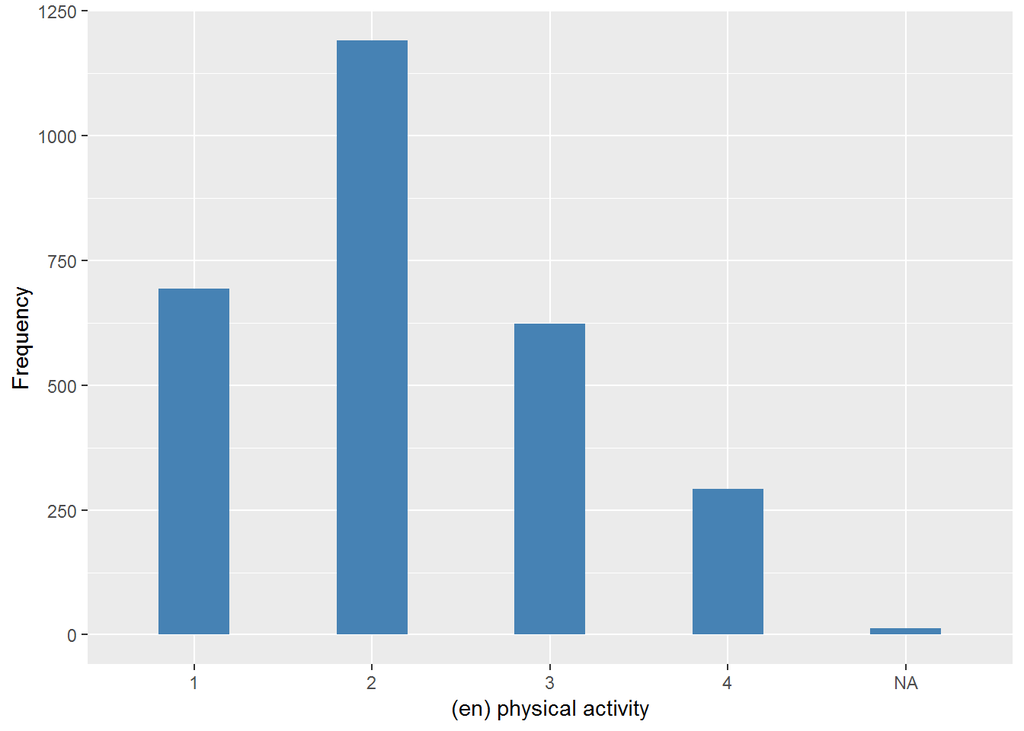

#### 2.1.1.2 Harmonisation algorithm

To compute the harmonize variable from the study-specific variable it has to be recoded as follows:

- `NA into 999`

```r
t1066_ds_cuba_w1 <- tibble(id = t1066_cuba_w1$id)
t1066_ds_cuba_w1$level_pa <- Recode(t1066_cuba_w1$PACTIVE, "NA='999'")
t1066_ds_cuba_w1$level_pa <- labelled(t1066_ds_cuba_w1$level_pa, labels = c(High = 1,
    Moderate = 2, Low = 3, Inactive = 4, Missing = 999, Do_not_know = 998, Refuse = 997,
    Not_applicable = 996, Does_not_answer = 995, Not_attempt_not_done = 994,
    Disable_to_measure = 993, Impute = 992, CAPI_interviewer_error = 991))
```

#### 2.1.1.3 Statistical description of the new harmonised variable

Activity level

| Sample size | Missing values |
| --- | --- |
| 2813 | 13 |

Category

|  | 1 | 2 | 3 | 4 |
| --- | --- | --- | --- | --- |
| Frequency | 694.00 | 1191.00 | 623.00 | 292.00 |
| Percentage | 24.67 | 42.34 | 22.15 | 10.38 |

Type of missing

|  | 991 | 992 | 993 | 994 | 995 | 996 | 997 | 998 | 999 | NA |
| --- | --- | --- | --- | --- | --- | --- | --- | --- | --- | --- |
| Frequency | 0 | 0 | 0 | 0 | 0 | 0 | 0 | 0 | 13.00 | 0 |
| Percentage | 0 | 0 | 0 | 0 | 0 | 0 | 0 | 0 | 0.46 | 0 |

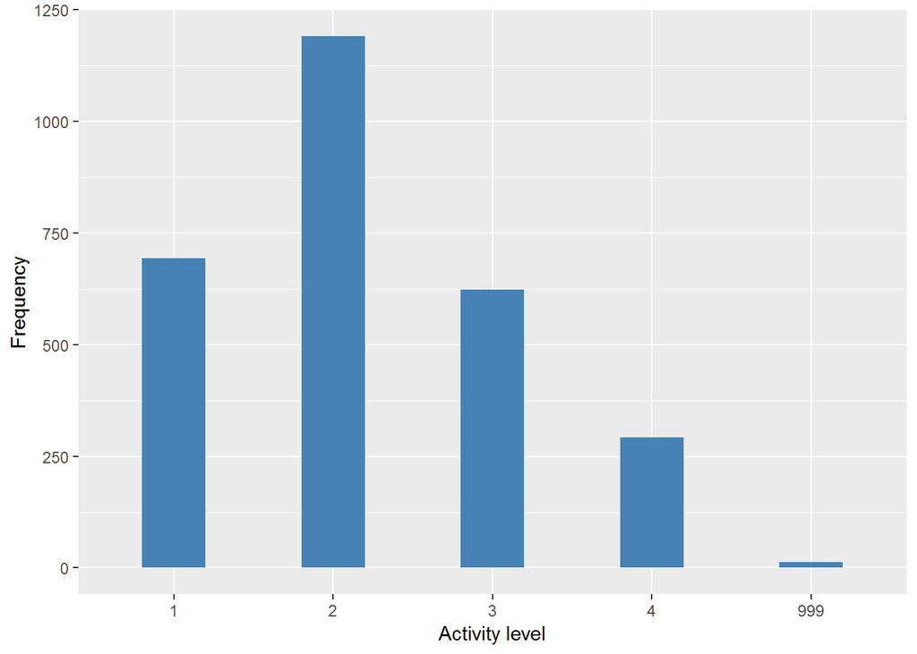

#### 2.1.1.4 Validation

|  | 1->1 | 2->2 | 3->3 | 4->4 | NA->999 |
| --- | --- | --- | --- | --- | --- |
| BeforeH | 694 | 1191 | 623 | 292 | 13 |
| AfterH | 694 | 1191 | 623 | 292 | 13 |

### 2.1.2 Wave 2

#### 2.1.2.1 Study-specific variable description

| **Name** | `f_PACTIVE` |
| --- | --- |
| **Label** | `physical activity` |
| **Table name** | `1066-Cuba-Followup` |
| **Categories** | `1 = very physically active` `2 = fairly` `3 = not very` `4 = not at all` |
| **Missings** | `0` `NA` |
| **Description** |  |

f_PACTIVE

| Sample size | Missing values |
| --- | --- |
| 2007 | 44 |

Category

|  | 1 | 2 | 3 | 4 |
| --- | --- | --- | --- | --- |
| Frequency | 522.00 | 729.00 | 442.00 | 270.00 |
| Percentage | 26.01 | 36.32 | 22.02 | 13.45 |

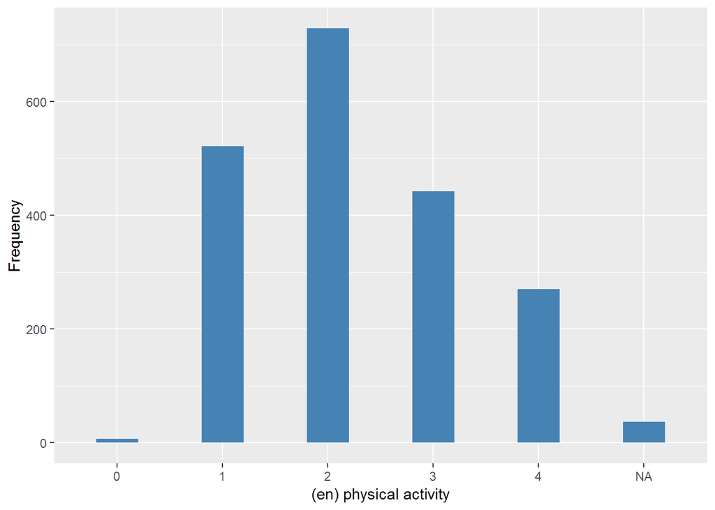

#### 2.1.2.2 Harmonisation algorithm

To compute the harmonize variable from the study-specific variable it has to be recoded as follows:

- `0 into 999`
- `NA into 999`

```r
t1066_ds_cuba_w2 <- tibble(id = t1066_cuba_w2$id)
t1066_ds_cuba_w2$level_pa <- Recode(t1066_cuba_w2$f_PACTIVE, "0 = '999';NA='999'")
t1066_ds_cuba_w2$level_pa <- labelled(t1066_ds_cuba_w2$level_pa, labels = c(High = 1,
    Moderate = 2, Low = 3, Inactive = 4, Missing = 999, Do_not_know = 998, Refuse = 997,
    Not_applicable = 996, Does_not_answer = 995, Not_attempt_not_done = 994,
    Disable_to_measure = 993, Impute = 992, CAPI_interviewer_error = 991))
```

#### 2.1.2.3 Statistical description of the new harmonised variable

Activity level

| Sample size | Missing values |
| --- | --- |
| 2007 | 44 |

Category

|  | 1 | 2 | 3 | 4 |
| --- | --- | --- | --- | --- |
| Frequency | 522.00 | 729.00 | 442.00 | 270.00 |
| Percentage | 26.01 | 36.32 | 22.02 | 13.45 |

Type of missing

|  | 991 | 992 | 993 | 994 | 995 | 996 | 997 | 998 | 999 | NA |
| --- | --- | --- | --- | --- | --- | --- | --- | --- | --- | --- |
| Frequency | 0 | 0 | 0 | 0 | 0 | 0 | 0 | 0 | 44.00 | 0 |
| Percentage | 0 | 0 | 0 | 0 | 0 | 0 | 0 | 0 | 2.19 | 0 |

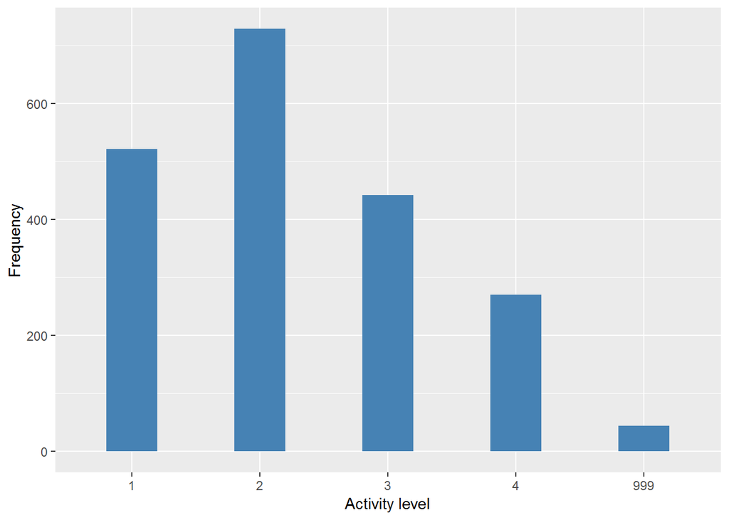

#### 2.1.2.4 Validation

|  | 1->1 | 2->2 | 3->3 | 4->4 | 0,NA->999 |
| --- | --- | --- | --- | --- | --- |
| BeforeH | 522 | 729 | 442 | 270 | 44 |
| AfterH | 522 | 729 | 442 | 270 | 44 |

## 2.2 India

### 2.2.1 Wave 1

#### 2.2.1.1 Study-specific variable description

| **Name** | `PACTIVE` |
| --- | --- |
| **Label** | `physical activity` |
| **Table name** | `1066-India-Baseline` |
| **Categories** | `1 = very physically active` `2 = fairly` `3 = not very` `4 = not at all` |
| **Missings** | `NA` |
| **Description** |  |

PACTIVE

| Sample size | Missing values |
| --- | --- |
| 2004 | 8 |

Category

|  | 1 | 2 | 3 | 4 |
| --- | --- | --- | --- | --- |
| Frequency | 402.00 | 1288.00 | 251.00 | 55.00 |
| Percentage | 20.06 | 64.27 | 12.52 | 2.74 |

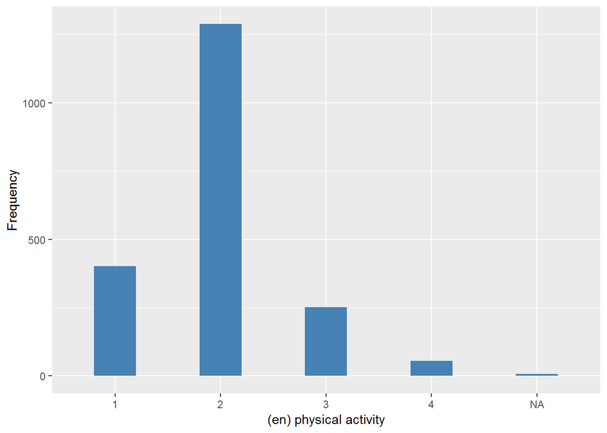

#### 2.2.1.2 Harmonisation algorithm

To compute the harmonize variable from the study-specific variable it has to be recoded as follows:

- `NA into 999`

```r
t1066_ds_india_w1 <- tibble(id = t1066_india_w1$id)
t1066_ds_india_w1$level_pa <- Recode(t1066_india_w1$PACTIVE, "NA='999'")
t1066_ds_india_w1$level_pa <- labelled(t1066_ds_india_w1$level_pa, labels = c(High = 1,
    Moderate = 2, Low = 3, Inactive = 4, Missing = 999, Do_not_know = 998, Refuse = 997,
    Not_applicable = 996, Does_not_answer = 995, Not_attempt_not_done = 994,
    Disable_to_measure = 993, Impute = 992, CAPI_interviewer_error = 991))
```

#### 2.2.1.3 Statistical description of the new harmonised variable

Activity level

| Sample size | Missing values |
| --- | --- |
| 2004 | 8 |

Category

|  | 1 | 2 | 3 | 4 |
| --- | --- | --- | --- | --- |
| Frequency | 402.00 | 1288.00 | 251.00 | 55.00 |
| Percentage | 20.06 | 64.27 | 12.52 | 2.74 |

Type of missing

|  | 991 | 992 | 993 | 994 | 995 | 996 | 997 | 998 | 999 | NA |
| --- | --- | --- | --- | --- | --- | --- | --- | --- | --- | --- |
| Frequency | 0 | 0 | 0 | 0 | 0 | 0 | 0 | 0 | 8.0 | 0 |
| Percentage | 0 | 0 | 0 | 0 | 0 | 0 | 0 | 0 | 0.4 | 0 |

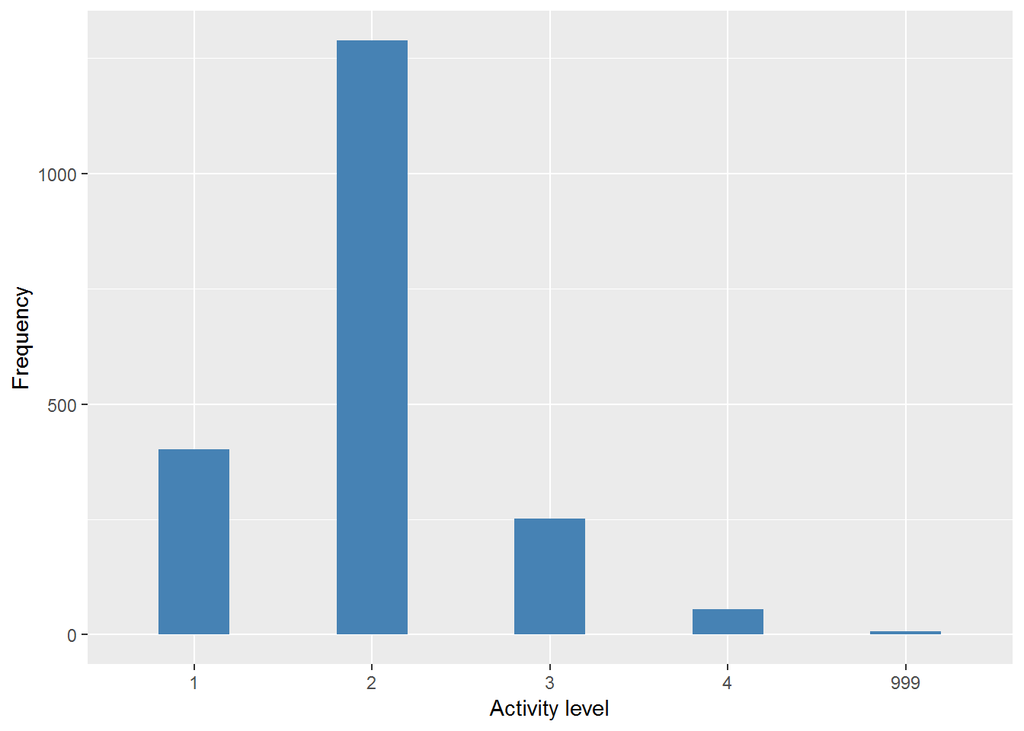

#### 2.2.1.4 Validation

|  | 1->1 | 2->2 | 3->3 | 4->4 | NA->999 |
| --- | --- | --- | --- | --- | --- |
| BeforeH | 402 | 1288 | 251 | 55 | 8 |
| AfterH | 402 | 1288 | 251 | 55 | 8 |

## 2.3 Urban China

### 2.3.1 Wave 1

#### 2.3.1.1 Study-specific variable description

| **Name** | `PACTIVE` |
| --- | --- |
| **Label** | `physical activity` |
| **Table name** | `1066-UrbanChina-Baseline` |
| **Categories** | `1 = very physically active` `2 = fairly` `3 = not very` `4 = not at all` |
| **Missings** |  |
| **Description** |  |

PACTIVE

| Sample size | Missing values |
| --- | --- |
| 1160 | 0 |

Category

|  | 1 | 2 | 3 | 4 |
| --- | --- | --- | --- | --- |
| Frequency | 149.00 | 576.00 | 333.00 | 102.00 |
| Percentage | 12.84 | 49.66 | 28.71 | 8.79 |

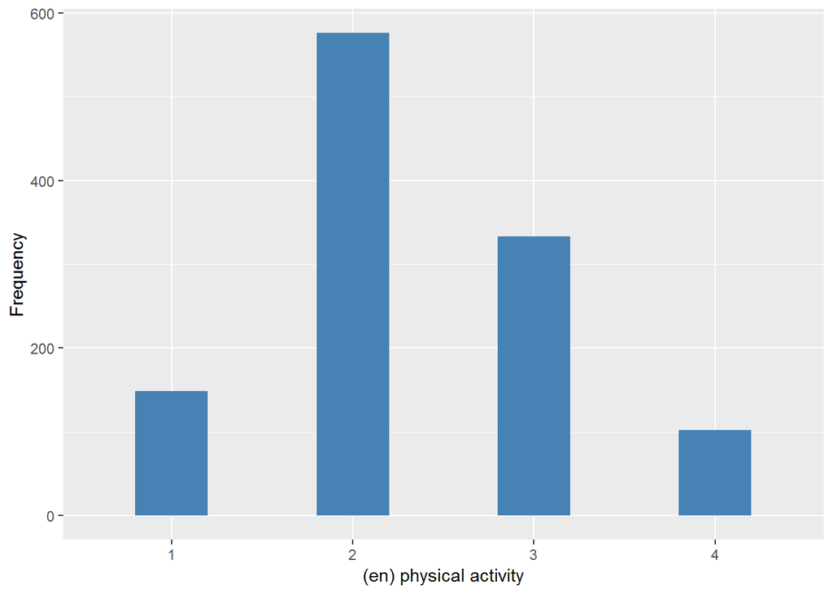

#### 2.3.1.2 Harmonisation algorithm

To compute the harmonize variable from the study-specific variable it has to be recoded as follows:

```r
t1066_ds_UCh_w1 <- tibble(id = t1066_UCh_w1$id)
t1066_ds_UCh_w1$level_pa <- Recode(t1066_UCh_w1$PACTIVE, "")
t1066_ds_UCh_w1$level_pa <- labelled(t1066_ds_UCh_w1$level_pa, labels = c(High = 1,
    Moderate = 2, Low = 3, Inactive = 4, Missing = 999, Do_not_know = 998, Refuse = 997,
    Not_applicable = 996, Does_not_answer = 995, Not_attempt_not_done = 994,
    Disable_to_measure = 993, Impute = 992, CAPI_interviewer_error = 991))
```

#### 2.3.1.3 Statistical description of the new harmonised variable

Activity level

| Sample size | Missing values |
| --- | --- |
| 1160 | 0 |

Category

|  | 1 | 2 | 3 | 4 |
| --- | --- | --- | --- | --- |
| Frequency | 149.00 | 576.00 | 333.00 | 102.00 |
| Percentage | 12.84 | 49.66 | 28.71 | 8.79 |

Type of missing

|  | 991 | 992 | 993 | 994 | 995 | 996 | 997 | 998 | 999 | NA |
| --- | --- | --- | --- | --- | --- | --- | --- | --- | --- | --- |
| Frequency | 0 | 0 | 0 | 0 | 0 | 0 | 0 | 0 | 0 | 0 |
| Percentage | 0 | 0 | 0 | 0 | 0 | 0 | 0 | 0 | 0 | 0 |

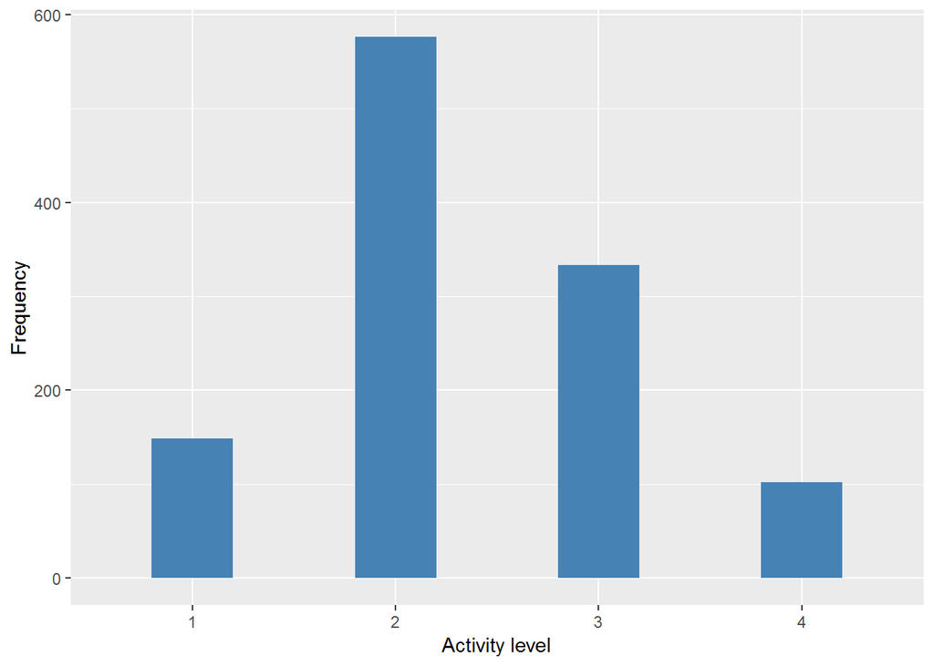

#### 2.3.1.4 Validation

|  | 1->1 | 2->2 | 3->3 | 4->4 |
| --- | --- | --- | --- | --- |
| BeforeH | 149 | 576 | 333 | 102 |
| AfterH | 149 | 576 | 333 | 102 |

### 2.3.2 Wave 2

#### 2.3.2.1 Study-specific variable description

| **Name** | `f_PACTIVE` |
| --- | --- |
| **Label** | `physical activity` |
| **Table name** | `1066-UrbanChina-Followup` |
| **Categories** | `1 = very physically active` `2 = fairly` `3 = not very` `4 = not at all` |
| **Missings** | `0` `NA` |
| **Description** |  |

f_PACTIVE

| Sample size | Missing values |
| --- | --- |
| 741 | 2 |

Category

|  | 1 | 2 | 3 | 4 |
| --- | --- | --- | --- | --- |
| Frequency | 124.00 | 224.00 | 262.00 | 129.00 |
| Percentage | 16.73 | 30.23 | 35.36 | 17.41 |

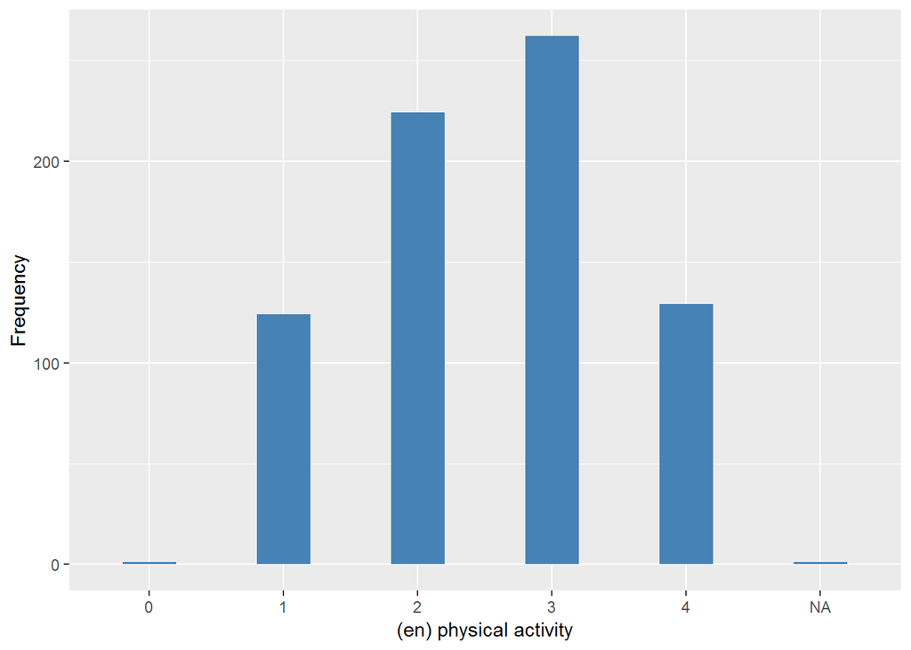

#### 2.3.2.2 Harmonisation algorithm

To compute the harmonize variable from the study-specific variable it has to be recoded as follows:

- `0 into 999`
- `NA into 999`

```r
t1066_ds_UCh_w2 <- tibble(id = t1066_UCh_w2$id)
t1066_ds_UCh_w2$level_pa <- Recode(t1066_UCh_w2$f_PACTIVE, "0 = '999';NA ='999'")
t1066_ds_UCh_w2$level_pa <- labelled(t1066_ds_UCh_w2$level_pa, labels = c(High = 1,
    Moderate = 2, Low = 3, Inactive = 4, Missing = 999, Do_not_know = 998, Refuse = 997,
    Not_applicable = 996, Does_not_answer = 995, Not_attempt_not_done = 994,
    Disable_to_measure = 993, Impute = 992, CAPI_interviewer_error = 991))
```

#### 2.3.2.3 Statistical description of the new harmonised variable

Activity level

| Sample size | Missing values |
| --- | --- |
| 741 | 2 |

Category

|  | 1 | 2 | 3 | 4 |
| --- | --- | --- | --- | --- |
| Frequency | 124.00 | 224.00 | 262.00 | 129.00 |
| Percentage | 16.73 | 30.23 | 35.36 | 17.41 |

Type of missing

|  | 991 | 992 | 993 | 994 | 995 | 996 | 997 | 998 | 999 | NA |
| --- | --- | --- | --- | --- | --- | --- | --- | --- | --- | --- |
| Frequency | 0 | 0 | 0 | 0 | 0 | 0 | 0 | 0 | 2.00 | 0 |
| Percentage | 0 | 0 | 0 | 0 | 0 | 0 | 0 | 0 | 0.27 | 0 |

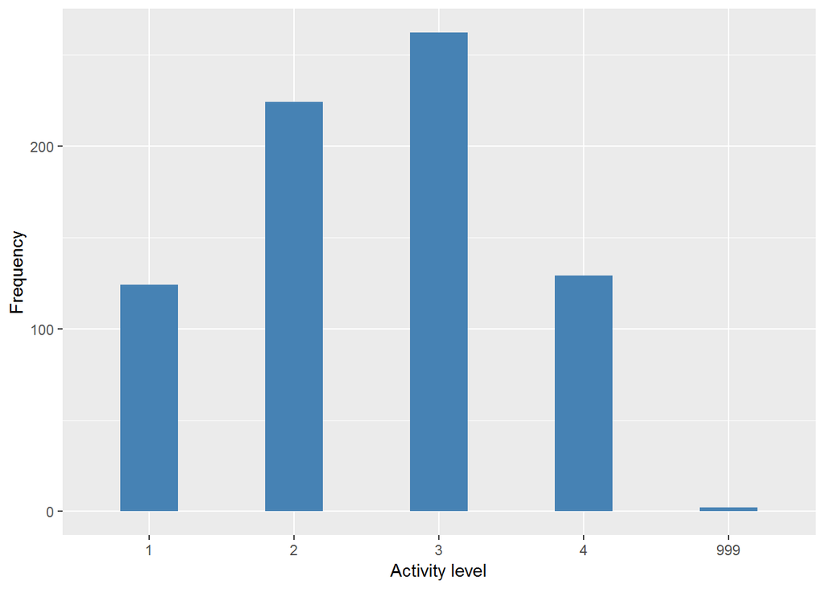

#### 2.3.2.4 Validation

|  | 1->1 | 2->2 | 3->3 | 4->4 | 0,NA->999 |
| --- | --- | --- | --- | --- | --- |
| BeforeH | 124 | 224 | 262 | 129 | 2 |
| AfterH | 124 | 224 | 262 | 129 | 2 |

## 2.4 Rural China

### 2.4.1 Wave 1

#### 2.4.1.1 Study-specific variable description

| **Name** | `PACTIVE` |
| --- | --- |
| **Label** | `physical activity` |
| **Table name** | `1066-RuralChina-Baseline` |
| **Categories** | `1 = very physically active` `2 = fairly` `3 = not very` `4 = not at all` |
| **Missings** | `NA` |
| **Description** |  |

PACTIVE

| Sample size | Missing values |
| --- | --- |
| 1002 | 3 |

Category

|  | 1 | 2 | 3 | 4 |
| --- | --- | --- | --- | --- |
| Frequency | 188.00 | 151.00 | 567.00 | 93.00 |
| Percentage | 18.76 | 15.07 | 56.59 | 9.28 |

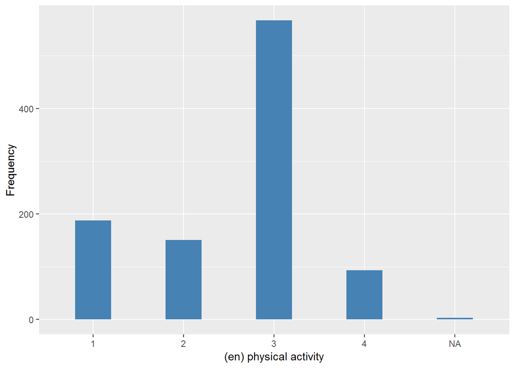

#### 2.4.1.2 Harmonisation algorithm

To compute the harmonize variable from the study-specific variable it has to be recoded as follows:

- `NA into 999`

```r
t1066_ds_RCh_w1 <- tibble(id = t1066_RCh_w1$id)
t1066_ds_RCh_w1$level_pa <- Recode(t1066_RCh_w1$PACTIVE, "NA='999'")
t1066_ds_RCh_w1$level_pa <- labelled(t1066_ds_RCh_w1$level_pa, labels = c(High = 1,
    Moderate = 2, Low = 3, Inactive = 4, Missing = 999, Do_not_know = 998, Refuse = 997,
    Not_applicable = 996, Does_not_answer = 995, Not_attempt_not_done = 994,
    Disable_to_measure = 993, Impute = 992, CAPI_interviewer_error = 991))
```

#### 2.4.1.3 Statistical description of the new harmonised variable

Activity level

| Sample size | Missing values |
| --- | --- |
| 1002 | 3 |

Category

|  | 1 | 2 | 3 | 4 |
| --- | --- | --- | --- | --- |
| Frequency | 188.00 | 151.00 | 567.00 | 93.00 |
| Percentage | 18.76 | 15.07 | 56.59 | 9.28 |

Type of missing

|  | 991 | 992 | 993 | 994 | 995 | 996 | 997 | 998 | 999 | NA |
| --- | --- | --- | --- | --- | --- | --- | --- | --- | --- | --- |
| Frequency | 0 | 0 | 0 | 0 | 0 | 0 | 0 | 0 | 3.0 | 0 |
| Percentage | 0 | 0 | 0 | 0 | 0 | 0 | 0 | 0 | 0.3 | 0 |

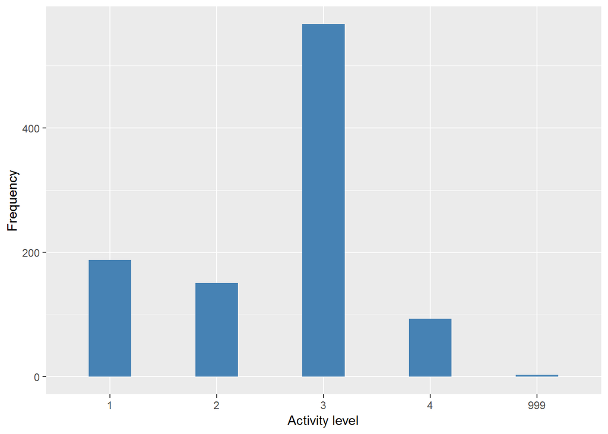

#### 2.4.1.4 Validation

|  | 1->1 | 2->2 | 3->3 | 4->4 | NA->999 |
| --- | --- | --- | --- | --- | --- |
| BeforeH | 188 | 151 | 567 | 93 | 3 |
| AfterH | 188 | 151 | 567 | 93 | 3 |

### 2.4.2 Wave 2

#### 2.4.2.1 Study-specific variable description

| **Name** | `f_PACTIVE` |
| --- | --- |
| **Label** | `physical activity` |
| **Table name** | `1066-RuralChina-Followup` |
| **Categories** | `1 = very physically active` `2 = fairly` `3 = not very` `4 = not at all` |
| **Missings** |  |
| **Description** |  |

f_PACTIVE

| Sample size | Missing values |
| --- | --- |
| 711 | 0 |

Category

|  | 1 | 2 | 3 | 4 |
| --- | --- | --- | --- | --- |
| Frequency | 157.00 | 183.00 | 185.00 | 186.00 |
| Percentage | 22.08 | 25.74 | 26.02 | 26.16 |

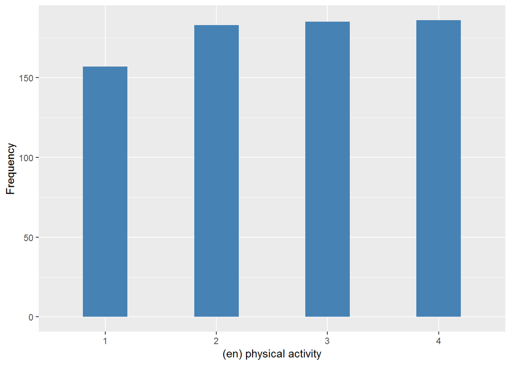

#### 2.4.2.2 Harmonisation algorithm

To compute the harmonize variable from the study-specific variable it has to be recoded as follows:

```r
t1066_ds_RCh_w2 <- tibble(id = t1066_RCh_w2$id)
t1066_ds_RCh_w2$level_pa <- Recode(t1066_RCh_w2$f_PACTIVE, "")
t1066_ds_RCh_w2$level_pa <- labelled(t1066_ds_RCh_w2$level_pa, labels = c(High = 1,
    Moderate = 2, Low = 3, Inactive = 4, Missing = 999, Do_not_know = 998, Refuse = 997,
    Not_applicable = 996, Does_not_answer = 995, Not_attempt_not_done = 994,
    Disable_to_measure = 993, Impute = 992, CAPI_interviewer_error = 991))
```

#### 2.4.2.3 Statistical description of the new harmonised variable

Activity level

| Sample size | Missing values |
| --- | --- |
| 711 | 0 |

Category

|  | 1 | 2 | 3 | 4 |
| --- | --- | --- | --- | --- |
| Frequency | 157.00 | 183.00 | 185.00 | 186.00 |
| Percentage | 22.08 | 25.74 | 26.02 | 26.16 |

Type of missing

|  | 991 | 992 | 993 | 994 | 995 | 996 | 997 | 998 | 999 | NA |
| --- | --- | --- | --- | --- | --- | --- | --- | --- | --- | --- |
| Frequency | 0 | 0 | 0 | 0 | 0 | 0 | 0 | 0 | 0 | 0 |
| Percentage | 0 | 0 | 0 | 0 | 0 | 0 | 0 | 0 | 0 | 0 |

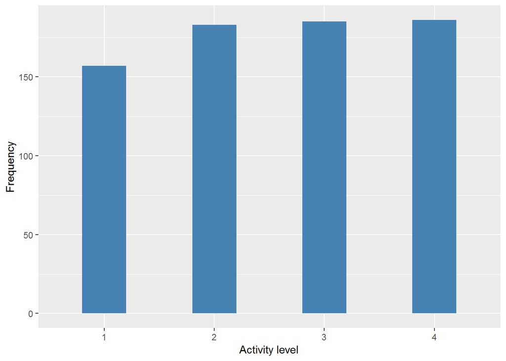

#### 2.4.2.4 Validation

|  | 1->1 | 2->2 | 3->3 | 4->4 |
| --- | --- | --- | --- | --- |
| BeforeH | 157 | 183 | 185 | 186 |
| AfterH | 157 | 183 | 185 | 186 |

## 2.5 Dominican Republic

### 2.5.1 Wave 1

#### 2.5.1.1 Study-specific variable description

| **Name** | `PACTIVE` |
| --- | --- |
| **Label** | `physical activity` |
| **Table name** | `1066-DominicanRepublic-Baseline` |
| **Categories** | `1 = very physically active` `2 = fairly` `3 = not very` `4 = not at all` |
| **Missings** | `NA` |
| **Description** |  |

PACTIVE

| Sample size | Missing values |
| --- | --- |
| 2011 | 7 |

Category

|  | 1 | 2 | 3 | 4 |
| --- | --- | --- | --- | --- |
| Frequency | 712.00 | 552.00 | 553.0 | 187.0 |
| Percentage | 35.41 | 27.45 | 27.5 | 9.3 |

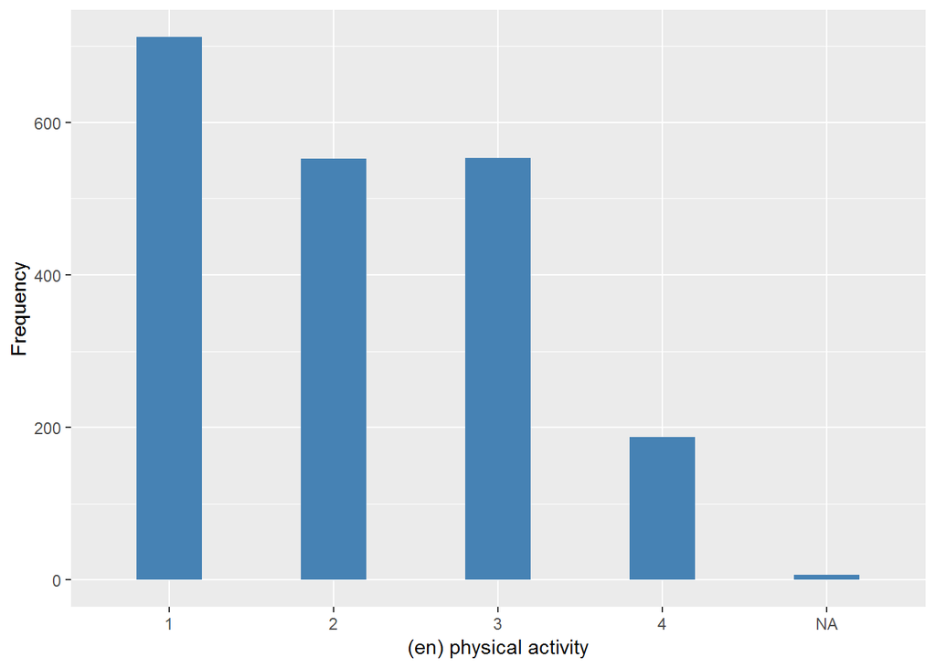

#### 2.5.1.2 Harmonisation algorithm

To compute the harmonize variable from the study-specific variable it has to be recoded as follows:

- `NA into 999`

```r
t1066_ds_DR_w1 <- tibble(id = t1066_DR_w1$id)
t1066_ds_DR_w1$level_pa <- Recode(t1066_DR_w1$PACTIVE, "NA='999'")
t1066_ds_DR_w1$level_pa <- labelled(t1066_ds_DR_w1$level_pa, labels = c(High = 1,
    Moderate = 2, Low = 3, Inactive = 4, Missing = 999, Do_not_know = 998, Refuse = 997,
    Not_applicable = 996, Does_not_answer = 995, Not_attempt_not_done = 994,
    Disable_to_measure = 993, Impute = 992, CAPI_interviewer_error = 991))
```

#### 2.5.1.3 Statistical description of the new harmonised variable

Activity level

| Sample size | Missing values |
| --- | --- |
| 2011 | 7 |

Category

|  | 1 | 2 | 3 | 4 |
| --- | --- | --- | --- | --- |
| Frequency | 712.00 | 552.00 | 553.0 | 187.0 |
| Percentage | 35.41 | 27.45 | 27.5 | 9.3 |

Type of missing

|  | 991 | 992 | 993 | 994 | 995 | 996 | 997 | 998 | 999 | NA |
| --- | --- | --- | --- | --- | --- | --- | --- | --- | --- | --- |
| Frequency | 0 | 0 | 0 | 0 | 0 | 0 | 0 | 0 | 7.00 | 0 |
| Percentage | 0 | 0 | 0 | 0 | 0 | 0 | 0 | 0 | 0.35 | 0 |

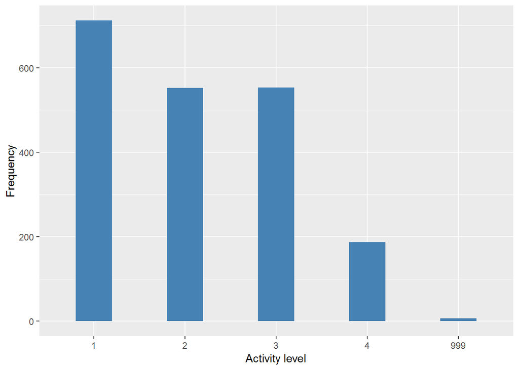

#### 2.5.1.4 Validation

|  | 1->1 | 2->2 | 3->3 | 4->4 | NA->999 |
| --- | --- | --- | --- | --- | --- |
| BeforeH | 712 | 552 | 553 | 187 | 7 |
| AfterH | 712 | 552 | 553 | 187 | 7 |

### 2.5.2 Wave 2

#### 2.5.2.1 Study-specific variable description

| **Name** | `f_PACTIVE` |
| --- | --- |
| **Label** | `physical activity` |
| **Table name** | `1066-DominicanRepublic-Followup` |
| **Categories** | `1 = very physically active` `2 = fairly` `3 = not very` `4 = not at all` |
| **Missings** | `NA` |
| **Description** |  |

f_PACTIVE

| Sample size | Missing values |
| --- | --- |
| 1197 | 15 |

Category

|  | 1 | 2 | 3 | 4 |
| --- | --- | --- | --- | --- |
| Frequency | 481.00 | 254.00 | 328.0 | 119.00 |
| Percentage | 40.18 | 21.22 | 27.4 | 9.94 |

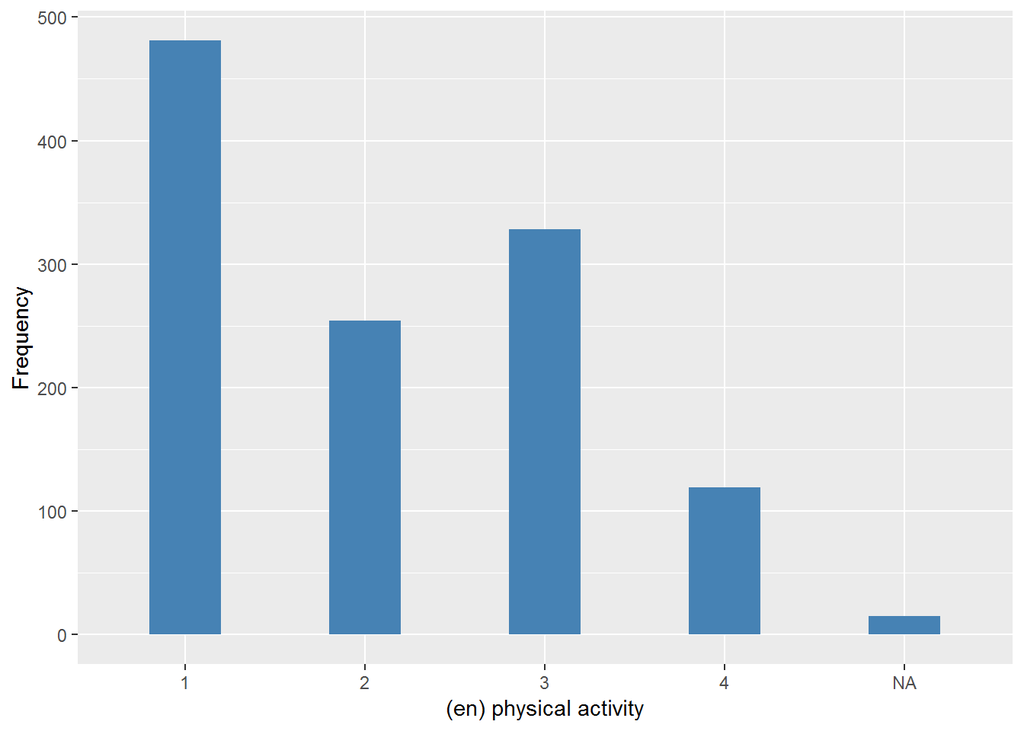

#### 2.5.2.2 Harmonisation algorithm

To compute the harmonize variable from the study-specific variable it has to be recoded as follows:

- `NA into 999`

```r
t1066_ds_DR_w2 <- tibble(id = t1066_DR_w2$id)
t1066_ds_DR_w2$level_pa <- Recode(t1066_DR_w2$f_PACTIVE, "NA='999'")
t1066_ds_DR_w2$level_pa <- labelled(t1066_ds_DR_w2$level_pa, labels = c(High = 1,
    Moderate = 2, Low = 3, Inactive = 4, Missing = 999, Do_not_know = 998, Refuse = 997,
    Not_applicable = 996, Does_not_answer = 995, Not_attempt_not_done = 994,
    Disable_to_measure = 993, Impute = 992, CAPI_interviewer_error = 991))
```

#### 2.5.2.3 Statistical description of the new harmonised variable

Activity level

| Sample size | Missing values |
| --- | --- |
| 1197 | 15 |

Category

|  | 1 | 2 | 3 | 4 |
| --- | --- | --- | --- | --- |
| Frequency | 481.00 | 254.00 | 328.0 | 119.00 |
| Percentage | 40.18 | 21.22 | 27.4 | 9.94 |

Type of missing

|  | 991 | 992 | 993 | 994 | 995 | 996 | 997 | 998 | 999 | NA |
| --- | --- | --- | --- | --- | --- | --- | --- | --- | --- | --- |
| Frequency | 0 | 0 | 0 | 0 | 0 | 0 | 0 | 0 | 15.00 | 0 |
| Percentage | 0 | 0 | 0 | 0 | 0 | 0 | 0 | 0 | 1.25 | 0 |

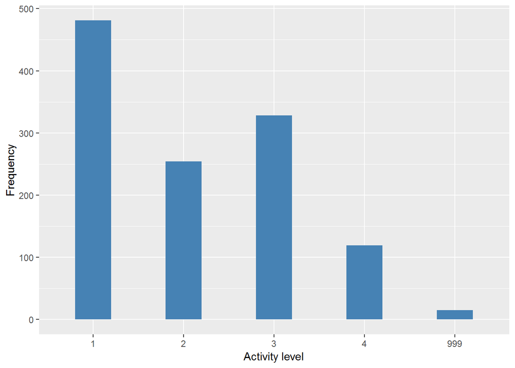

#### 2.5.2.4 Validation

|  | 1->1 | 2->2 | 3->3 | 4->4 | NA->999 |
| --- | --- | --- | --- | --- | --- |
| BeforeH | 481 | 254 | 328 | 119 | 15 |
| AfterH | 481 | 254 | 328 | 119 | 15 |

## 2.6 Venezuela

### 2.6.1 Wave 1

#### 2.6.1.1 Study-specific variable description

| **Name** | `PACTIVE` |
| --- | --- |
| **Label** | `physical activity` |
| **Table name** | `1066-Venezuela-Baseline` |
| **Categories** | `1 = very physically active` `2 = fairly` `3 = not very` `4 = not at all` |
| **Missings** | `NA` |
| **Description** |  |

PACTIVE

| Sample size | Missing values |
| --- | --- |
| 1965 | 60 |

Category

|  | 1 | 2 | 3 | 4 |
| --- | --- | --- | --- | --- |
| Frequency | 346.00 | 892.00 | 563.00 | 104.00 |
| Percentage | 17.61 | 45.39 | 28.65 | 5.29 |

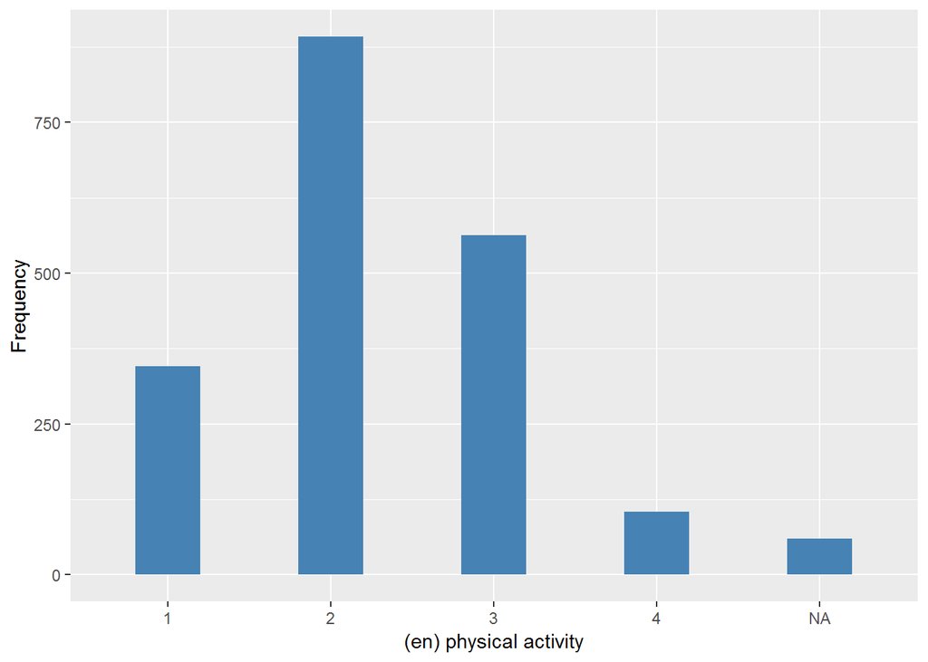

#### 2.6.1.2 Harmonisation algorithm

To compute the harmonize variable from the study-specific variable it has to be recoded as follows:

- `NA into 999`

```r
t1066_ds_Ven_w1 <- tibble(id = t1066_Ven_w1$id)
t1066_ds_Ven_w1$level_pa <- Recode(t1066_Ven_w1$PACTIVE, "NA='999'")
t1066_ds_Ven_w1$level_pa <- labelled(t1066_ds_Ven_w1$level_pa, labels = c(High = 1,
    Moderate = 2, Low = 3, Inactive = 4, Missing = 999, Do_not_know = 998, Refuse = 997,
    Not_applicable = 996, Does_not_answer = 995, Not_attempt_not_done = 994,
    Disable_to_measure = 993, Impute = 992, CAPI_interviewer_error = 991))
```

#### 2.6.1.3 Statistical description of the new harmonised variable

Activity level

| Sample size | Missing values |
| --- | --- |
| 1965 | 60 |

Category

|  | 1 | 2 | 3 | 4 |
| --- | --- | --- | --- | --- |
| Frequency | 346.00 | 892.00 | 563.00 | 104.00 |
| Percentage | 17.61 | 45.39 | 28.65 | 5.29 |

Type of missing

|  | 991 | 992 | 993 | 994 | 995 | 996 | 997 | 998 | 999 | NA |
| --- | --- | --- | --- | --- | --- | --- | --- | --- | --- | --- |
| Frequency | 0 | 0 | 0 | 0 | 0 | 0 | 0 | 0 | 60.00 | 0 |
| Percentage | 0 | 0 | 0 | 0 | 0 | 0 | 0 | 0 | 3.05 | 0 |

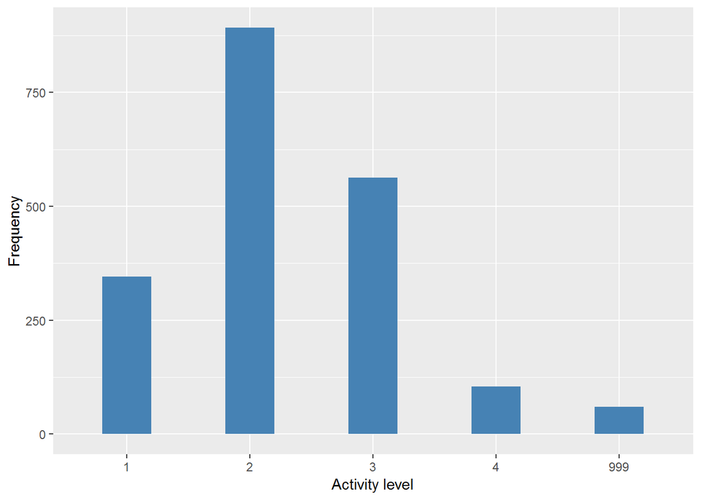

#### 2.6.1.4 Validation

|  | 1->1 | 2->2 | 3->3 | 4->4 | NA->999 |
| --- | --- | --- | --- | --- | --- |
| BeforeH | 346 | 892 | 563 | 104 | 60 |
| AfterH | 346 | 892 | 563 | 104 | 60 |

### 2.6.2 Wave 2

#### 2.6.2.1 Study-specific variable description

| **Name** | `f_PACTIVE` |
| --- | --- |
| **Label** | `physical activity` |
| **Table name** | `1066-Venezuela-Followup` |
| **Categories** | `1 = very physically active` `2 = fairly` `3 = not very` `4 = not at all` |
| **Missings** | `NA` |
| **Description** |  |

f_PACTIVE

| Sample size | Missing values |
| --- | --- |
| 1257 | 12 |

Category

|  | 1 | 2 | 3 | 4 |
| --- | --- | --- | --- | --- |
| Frequency | 317.00 | 430.00 | 440 | 58.00 |
| Percentage | 25.22 | 34.21 | 35 | 4.61 |

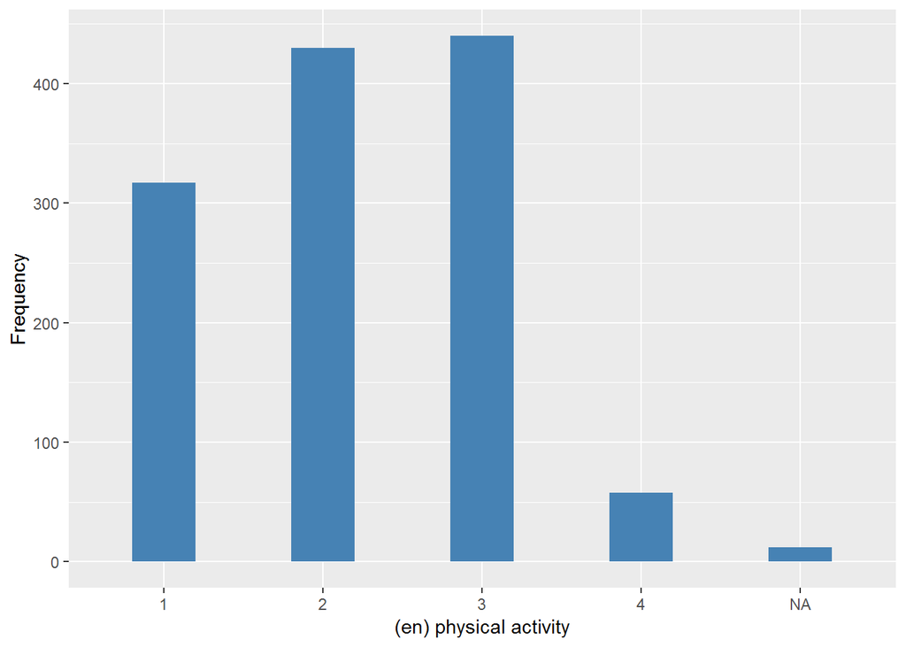

#### 2.6.2.2 Harmonisation algorithm

To compute the harmonize variable from the study-specific variable it has to be recoded as follows:

- `NA into 999`

```r
t1066_ds_Ven_w2 <- tibble(id = t1066_Ven_w2$id)
t1066_ds_Ven_w2$level_pa <- Recode(t1066_Ven_w2$f_PACTIVE, "NA='999'")
t1066_ds_Ven_w2$level_pa <- labelled(t1066_ds_Ven_w2$level_pa, labels = c(High = 1,
    Moderate = 2, Low = 3, Inactive = 4, Missing = 999, Do_not_know = 998, Refuse = 997,
    Not_applicable = 996, Does_not_answer = 995, Not_attempt_not_done = 994,
    Disable_to_measure = 993, Impute = 992, CAPI_interviewer_error = 991))
```

#### 2.6.2.3 Statistical description of the new harmonised variable

Activity level

| Sample size | Missing values |
| --- | --- |
| 1257 | 12 |

Category

|  | 1 | 2 | 3 | 4 |
| --- | --- | --- | --- | --- |
| Frequency | 317.00 | 430.00 | 440 | 58.00 |
| Percentage | 25.22 | 34.21 | 35 | 4.61 |

Type of missing

|  | 991 | 992 | 993 | 994 | 995 | 996 | 997 | 998 | 999 | NA |
| --- | --- | --- | --- | --- | --- | --- | --- | --- | --- | --- |
| Frequency | 0 | 0 | 0 | 0 | 0 | 0 | 0 | 0 | 12.00 | 0 |
| Percentage | 0 | 0 | 0 | 0 | 0 | 0 | 0 | 0 | 0.95 | 0 |

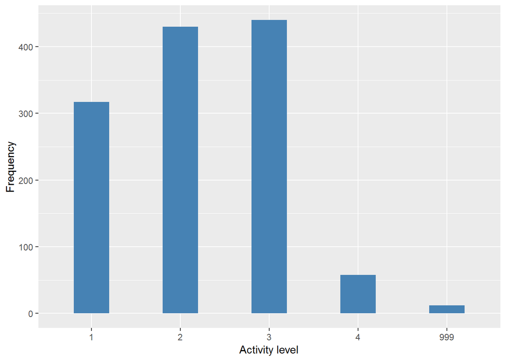

#### 2.6.2.4 Validation

|  | 1->1 | 2->2 | 3->3 | 4->4 | NA->999 |
| --- | --- | --- | --- | --- | --- |
| BeforeH | 317 | 430 | 440 | 58 | 12 |
| AfterH | 317 | 430 | 440 | 58 | 12 |

## 2.7 Urban Peru

### 2.7.1 Wave 1

#### 2.7.1.1 Study-specific variable description

| **Name** | `PACTIVE` |
| --- | --- |
| **Label** | `physical activity` |
| **Table name** | `1066-UrbanPeru-Baseline` |
| **Categories** | `1 = very physically active` `2 = fairly` `3 = not very` `4 = not at all` |
| **Missings** | `NA` |
| **Description** |  |

PACTIVE

| Sample size | Missing values |
| --- | --- |
| 1381 | 9 |

Category

|  | 1 | 2 | 3 | 4 |
| --- | --- | --- | --- | --- |
| Frequency | 406.0 | 537.00 | 354.00 | 75.00 |
| Percentage | 29.4 | 38.88 | 25.63 | 5.43 |

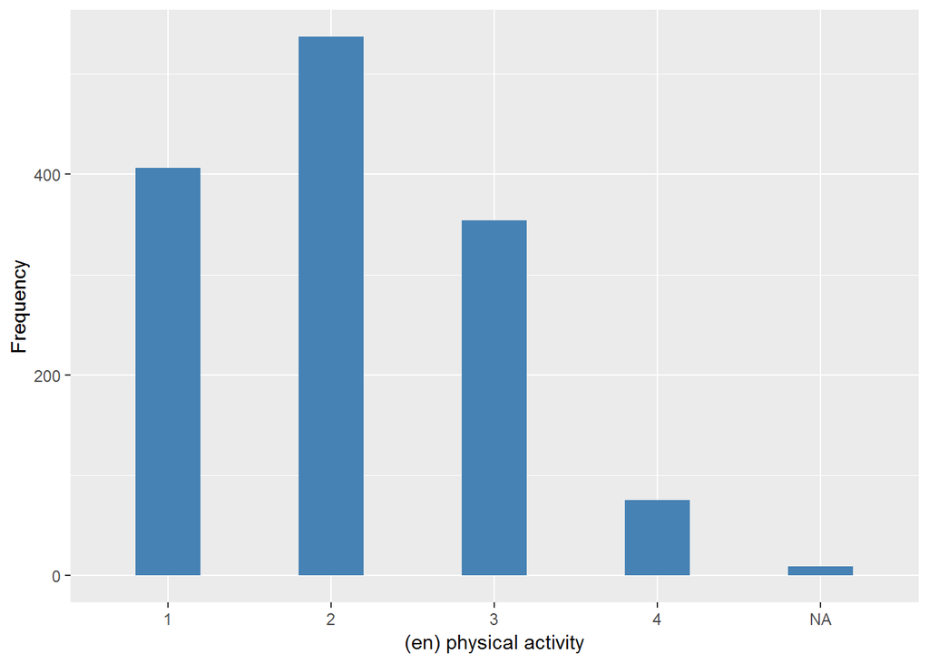

#### 2.7.1.2 Harmonisation algorithm

To compute the harmonize variable from the study-specific variable it has to be recoded as follows:

- `NA into 999`

```r
t1066_ds_UP_w1 <- tibble(id = t1066_UP_w1$id)
t1066_ds_UP_w1$level_pa <- Recode(t1066_UP_w1$PACTIVE, "NA='999'")
t1066_ds_UP_w1$level_pa <- labelled(t1066_ds_UP_w1$level_pa, labels = c(High = 1,
    Moderate = 2, Low = 3, Inactive = 4, Missing = 999, Do_not_know = 998, Refuse = 997,
    Not_applicable = 996, Does_not_answer = 995, Not_attempt_not_done = 994,
    Disable_to_measure = 993, Impute = 992, CAPI_interviewer_error = 991))
```

#### 2.7.1.3 Statistical description of the new harmonised variable

Activity level

| Sample size | Missing values |
| --- | --- |
| 1381 | 9 |

Category

|  | 1 | 2 | 3 | 4 |
| --- | --- | --- | --- | --- |
| Frequency | 406.0 | 537.00 | 354.00 | 75.00 |
| Percentage | 29.4 | 38.88 | 25.63 | 5.43 |

Type of missing

|  | 991 | 992 | 993 | 994 | 995 | 996 | 997 | 998 | 999 | NA |
| --- | --- | --- | --- | --- | --- | --- | --- | --- | --- | --- |
| Frequency | 0 | 0 | 0 | 0 | 0 | 0 | 0 | 0 | 9.00 | 0 |
| Percentage | 0 | 0 | 0 | 0 | 0 | 0 | 0 | 0 | 0.65 | 0 |

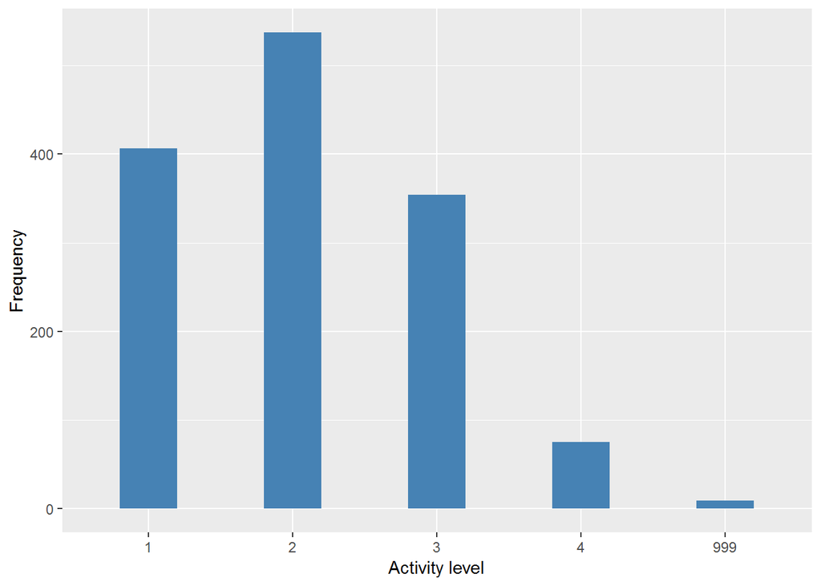

#### 2.7.1.4 Validation

|  | 1->1 | 2->2 | 3->3 | 4->4 | NA->999 |
| --- | --- | --- | --- | --- | --- |
| BeforeH | 406 | 537 | 354 | 75 | 9 |
| AfterH | 406 | 537 | 354 | 75 | 9 |

### 2.7.2 Wave 2

#### 2.7.2.1 Study-specific variable description

| **Name** | `f_PACTIVE` |
| --- | --- |
| **Label** | `physical activity` |
| **Table name** | `1066-UrbanPeru-Followup` |
| **Categories** | `1 = very physically active` `2 = fairly` `3 = not very` `4 = not at all` |
| **Missings** |  |
| **Description** |  |

f_PACTIVE

| Sample size | Missing values |
| --- | --- |
| 890 | 0 |

Category

|  | 1 | 2 | 3 | 4 |
| --- | --- | --- | --- | --- |
| Frequency | 212.00 | 309.00 | 292.00 | 77.00 |
| Percentage | 23.82 | 34.72 | 32.81 | 8.65 |

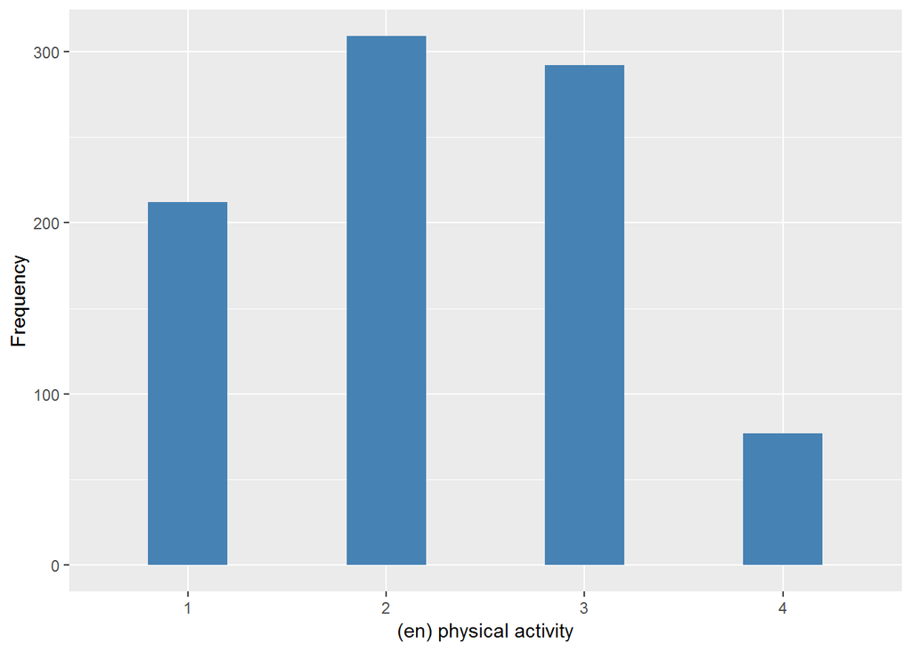

#### 2.7.2.2 Harmonisation algorithm

To compute the harmonize variable from the study-specific variable it has to be recoded as follows:

```r
t1066_ds_UP_w2 <- tibble(id = t1066_UP_w2$id)
t1066_ds_UP_w2$level_pa <- Recode(t1066_UP_w2$f_PACTIVE, "")
t1066_ds_UP_w2$level_pa <- labelled(t1066_ds_UP_w2$level_pa, labels = c(High = 1,
    Moderate = 2, Low = 3, Inactive = 4, Missing = 999, Do_not_know = 998, Refuse = 997,
    Not_applicable = 996, Does_not_answer = 995, Not_attempt_not_done = 994,
    Disable_to_measure = 993, Impute = 992, CAPI_interviewer_error = 991))
```

#### 2.7.2.3 Statistical description of the new harmonised variable

Activity level

| Sample size | Missing values |
| --- | --- |
| 890 | 0 |

Category

|  | 1 | 2 | 3 | 4 |
| --- | --- | --- | --- | --- |
| Frequency | 212.00 | 309.00 | 292.00 | 77.00 |
| Percentage | 23.82 | 34.72 | 32.81 | 8.65 |

Type of missing

|  | 991 | 992 | 993 | 994 | 995 | 996 | 997 | 998 | 999 | NA |
| --- | --- | --- | --- | --- | --- | --- | --- | --- | --- | --- |
| Frequency | 0 | 0 | 0 | 0 | 0 | 0 | 0 | 0 | 0 | 0 |
| Percentage | 0 | 0 | 0 | 0 | 0 | 0 | 0 | 0 | 0 | 0 |

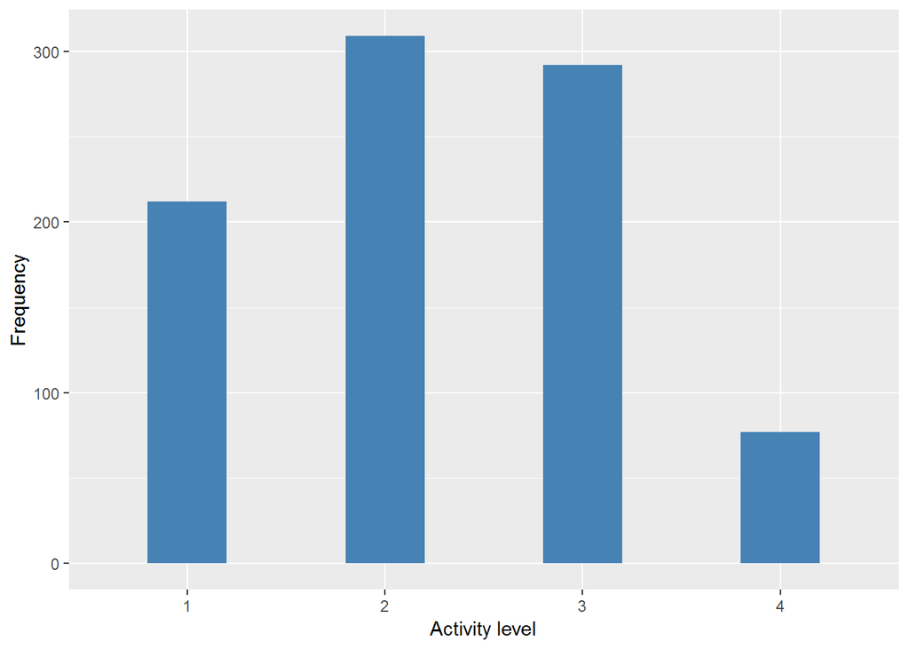

#### 2.7.2.4 Validation

|  | 1->1 | 2->2 | 3->3 | 4->4 |
| --- | --- | --- | --- | --- |
| BeforeH | 212 | 309 | 292 | 77 |
| AfterH | 212 | 309 | 292 | 77 |

## 2.8 Rural Peru

### 2.8.1 Wave 1

#### 2.8.1.1 Study-specific variable description

| **Name** | `PACTIVE` |
| --- | --- |
| **Label** | `physical activity` |
| **Table name** | `1066-RuralPeru-Baseline` |
| **Categories** | `1 = very physically active` `2 = fairly` `3 = not very` `4 = not at all` |
| **Missings** | `NA` |
| **Description** |  |

PACTIVE

| Sample size | Missing values |
| --- | --- |
| 552 | 3 |

Category

|  | 1 | 2 | 3 | 4 |
| --- | --- | --- | --- | --- |
| Frequency | 159.0 | 232.00 | 147.00 | 11.00 |
| Percentage | 28.8 | 42.03 | 26.63 | 1.99 |

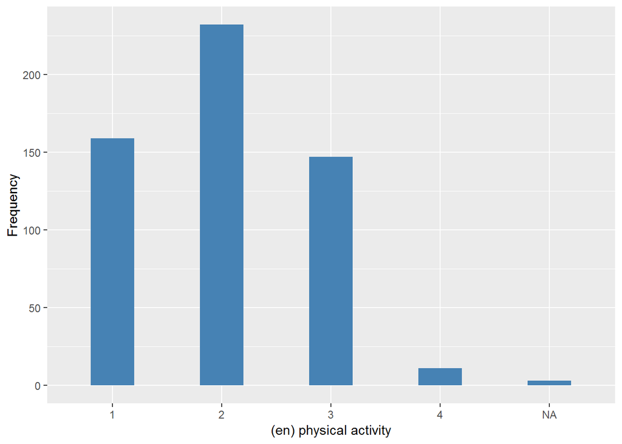

#### 2.8.1.2 Harmonisation algorithm

To compute the harmonize variable from the study-specific variable it has to be recoded as follows:

- `NA into 999`

```r
t1066_ds_RP_w1 <- tibble(id = t1066_RP_w1$id)
t1066_ds_RP_w1$level_pa <- Recode(t1066_RP_w1$PACTIVE, "NA = '999'")
t1066_ds_RP_w1$level_pa <- labelled(t1066_ds_RP_w1$level_pa, labels = c(High = 1,
    Moderate = 2, Low = 3, Inactive = 4, Missing = 999, Do_not_know = 998, Refuse = 997,
    Not_applicable = 996, Does_not_answer = 995, Not_attempt_not_done = 994,
    Disable_to_measure = 993, Impute = 992, CAPI_interviewer_error = 991))
```

#### 2.8.1.3 Statistical description of the new harmonised variable

Activity level

| Sample size | Missing values |
| --- | --- |
| 552 | 3 |

Category

|  | 1 | 2 | 3 | 4 |
| --- | --- | --- | --- | --- |
| Frequency | 159.0 | 232.00 | 147.00 | 11.00 |
| Percentage | 28.8 | 42.03 | 26.63 | 1.99 |

Type of missing

|  | 991 | 992 | 993 | 994 | 995 | 996 | 997 | 998 | 999 | NA |
| --- | --- | --- | --- | --- | --- | --- | --- | --- | --- | --- |
| Frequency | 0 | 0 | 0 | 0 | 0 | 0 | 0 | 0 | 3.00 | 0 |
| Percentage | 0 | 0 | 0 | 0 | 0 | 0 | 0 | 0 | 0.54 | 0 |

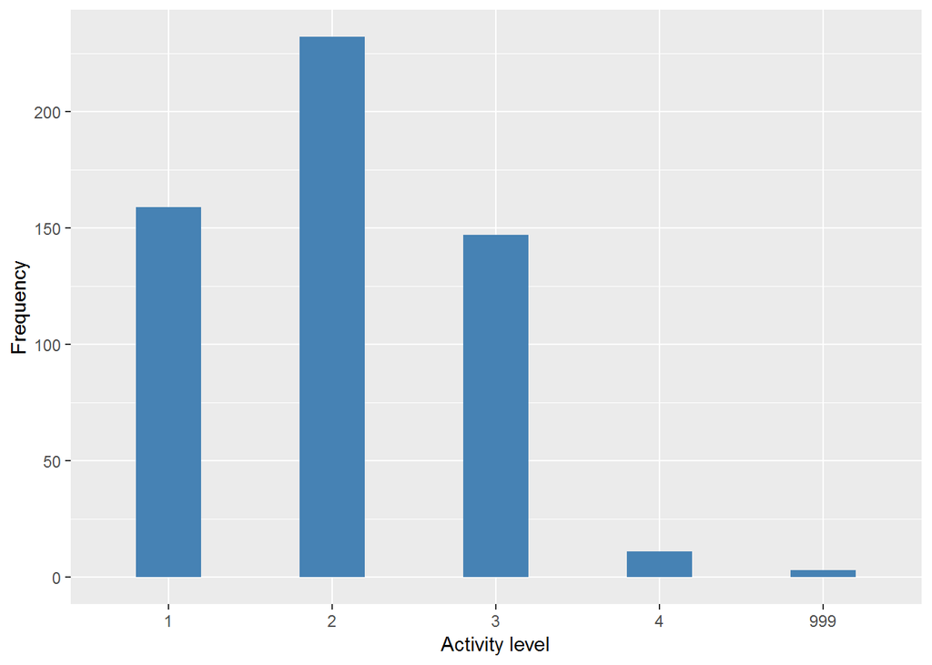

#### 2.8.1.4 Validation

|  | 1->1 | 2->2 | 3->3 | 4->4 | NA->999 |
| --- | --- | --- | --- | --- | --- |
| BeforeH | 159 | 232 | 147 | 11 | 3 |
| AfterH | 159 | 232 | 147 | 11 | 3 |

### 2.8.2 Wave 2

#### 2.8.2.1 Study-specific variable description

| **Name** | `f_PACTIVE` |
| --- | --- |
| **Label** | `physical activity` |
| **Table name** | `1066-RuralPeru-Followup` |
| **Categories** | `1 = very physically active` `2 = fairly` `3 = not very` `4 = not at all` |
| **Missings** |  |
| **Description** |  |

f_PACTIVE

| Sample size | Missing values |
| --- | --- |
| 421 | 0 |

Category

|  | 1 | 2 | 3 | 4 |
| --- | --- | --- | --- | --- |
| Frequency | 194.00 | 103.00 | 106.00 | 18.00 |
| Percentage | 46.08 | 24.47 | 25.18 | 4.28 |

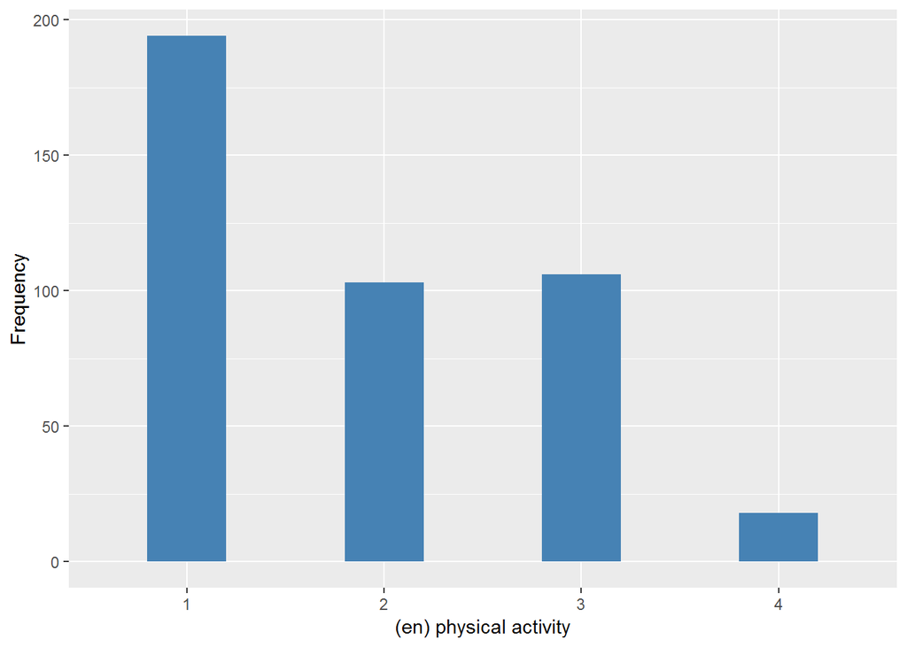

#### 2.8.2.2 Harmonisation algorithm

To compute the harmonize variable from the study-specific variable it has to be recoded as follows:

```r
t1066_ds_RP_w2 <- tibble(id = t1066_RP_w2$id)
t1066_ds_RP_w2$level_pa <- Recode(t1066_RP_w2$f_PACTIVE, "")
t1066_ds_RP_w2$level_pa <- labelled(t1066_ds_RP_w2$level_pa, labels = c(High = 1,
    Moderate = 2, Low = 3, Inactive = 4, Missing = 999, Do_not_know = 998, Refuse = 997,
    Not_applicable = 996, Does_not_answer = 995, Not_attempt_not_done = 994,
    Disable_to_measure = 993, Impute = 992, CAPI_interviewer_error = 991))
```

#### 2.8.2.3 Statistical description of the new harmonised variable

Activity level

| Sample size | Missing values |
| --- | --- |
| 421 | 0 |

Category

|  | 1 | 2 | 3 | 4 |
| --- | --- | --- | --- | --- |
| Frequency | 194.00 | 103.00 | 106.00 | 18.00 |
| Percentage | 46.08 | 24.47 | 25.18 | 4.28 |

Type of missing

|  | 991 | 992 | 993 | 994 | 995 | 996 | 997 | 998 | 999 | NA |
| --- | --- | --- | --- | --- | --- | --- | --- | --- | --- | --- |
| Frequency | 0 | 0 | 0 | 0 | 0 | 0 | 0 | 0 | 0 | 0 |
| Percentage | 0 | 0 | 0 | 0 | 0 | 0 | 0 | 0 | 0 | 0 |

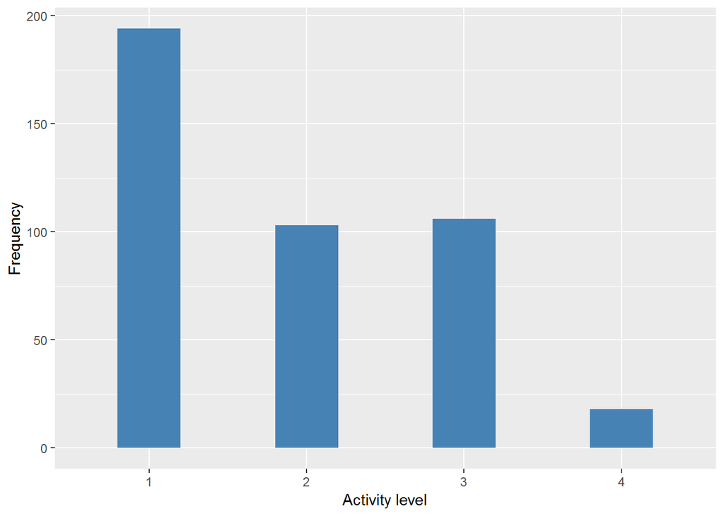

#### 2.8.2.4 Validation

|  | 1->1 | 2->2 | 3->3 | 4->4 |
| --- | --- | --- | --- | --- |
| BeforeH | 194 | 103 | 106 | 18 |
| AfterH | 194 | 103 | 106 | 18 |

## 2.9 Urban Mexico

### 2.9.1 Wave 1

#### 2.9.1.1 Study-specific variable description

| **Name** | `PACTIVE` |
| --- | --- |
| **Label** | `physical activity` |
| **Table name** | `1066-UrbanMexico-Baseline` |
| **Categories** | `1 = very physically active` `2 = fairly` `3 = not very` `4 = not at all` |
| **Missings** | `NA` |
| **Description** |  |

PACTIVE

| Sample size | Missing values |
| --- | --- |
| 1003 | 6 |

Category

|  | 1 | 2 | 3 | 4 |
| --- | --- | --- | --- | --- |
| Frequency | 197.00 | 418.00 | 319.0 | 63.00 |
| Percentage | 19.64 | 41.67 | 31.8 | 6.28 |

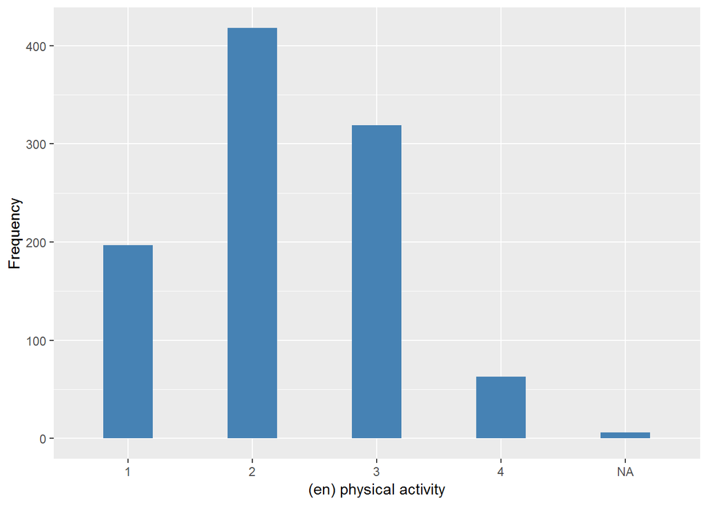

#### 2.9.1.2 Harmonisation algorithm

To compute the harmonize variable from the study-specific variable it has to be recoded as follows:

- `NA into 999`

```r
t1066_ds_UM_w1 <- tibble(id = t1066_UM_w1$id)
t1066_ds_UM_w1$level_pa <- Recode(t1066_UM_w1$PACTIVE, "NA='999'")
t1066_ds_UM_w1$level_pa <- labelled(t1066_ds_UM_w1$level_pa, labels = c(High = 1,
    Moderate = 2, Low = 3, Inactive = 4, Missing = 999, Do_not_know = 998, Refuse = 997,
    Not_applicable = 996, Does_not_answer = 995, Not_attempt_not_done = 994,
    Disable_to_measure = 993, Impute = 992, CAPI_interviewer_error = 991))
```

#### 2.9.1.3 Statistical description of the new harmonised variable

Activity level

| Sample size | Missing values |
| --- | --- |
| 1003 | 6 |

Category

|  | 1 | 2 | 3 | 4 |
| --- | --- | --- | --- | --- |
| Frequency | 197.00 | 418.00 | 319.0 | 63.00 |
| Percentage | 19.64 | 41.67 | 31.8 | 6.28 |

Type of missing

|  | 991 | 992 | 993 | 994 | 995 | 996 | 997 | 998 | 999 | NA |
| --- | --- | --- | --- | --- | --- | --- | --- | --- | --- | --- |
| Frequency | 0 | 0 | 0 | 0 | 0 | 0 | 0 | 0 | 6.0 | 0 |
| Percentage | 0 | 0 | 0 | 0 | 0 | 0 | 0 | 0 | 0.6 | 0 |

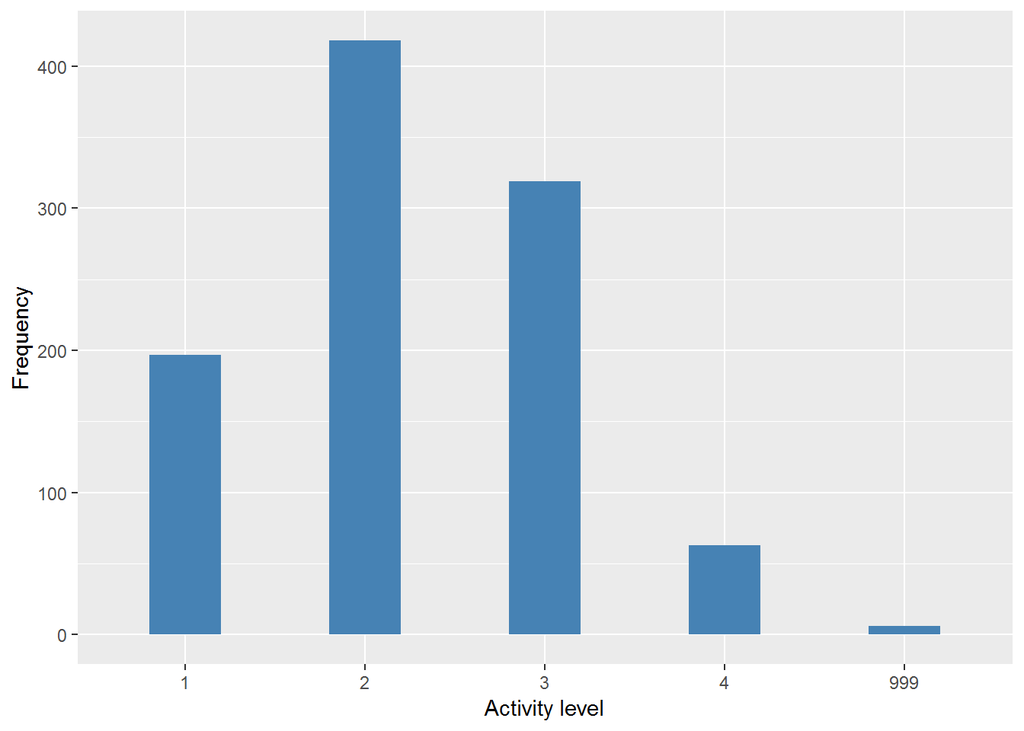

#### 2.9.1.4 Validation

|  | 1->1 | 2->2 | 3->3 | 4->4 | NA->999 |
| --- | --- | --- | --- | --- | --- |
| BeforeH | 197 | 418 | 319 | 63 | 6 |
| AfterH | 197 | 418 | 319 | 63 | 6 |